# Day2: マッチング

Jaehyun Song

8/26/2020

# パッケージとデータの読み込み

```r
library(tidyverse)
library(MatchIt)
library(WeightIt)
library(BalanceR)
library(cobalt)

# cobaltパッケージが提供するデータセットの読み込み
data("lalonde", package = "cobalt")

Day2_df <- lalonde
```

マッチングにおける古典的なデータセット、`lalonde`を読み込みました。`data(lalonde, package = "cobalt")`を入力するだけで、`cobalt`パッケージ内の`laonde`という名前のデータフレームが作業環境上に読み込まれます。このデータを`Day2_df`という名のオブジェクトとして改めて保存しておきます。

それでは、データの中身を確認してみましょう。普通にコンソール上で`lalonde`を打っても良いですが、`DT`パッケージの`datatable()`を使うと見やすい表形式で出力されます。

```r
DT::datatable(Day2_df)
```

|  | treat | age | educ | race | married | nodegree | re74 | re75 | re78 |
| --- | --- | --- | --- | --- | --- | --- | --- | --- | --- |
| 1 | 1 | 37 | 11 | black | 1 | 1 | 0 | 0 | 9930.046 |
| 2 | 1 | 22 | 9 | hispan | 0 | 1 | 0 | 0 | 3595.894 |
| 3 | 1 | 30 | 12 | black | 0 | 0 | 0 | 0 | 24909.45 |
| 4 | 1 | 27 | 11 | black | 0 | 1 | 0 | 0 | 7506.146 |
| 5 | 1 | 33 | 8 | black | 0 | 1 | 0 | 0 | 289.7899 |
| 6 | 1 | 22 | 9 | black | 0 | 1 | 0 | 0 | 4056.494 |
| 7 | 1 | 23 | 12 | black | 0 | 0 | 0 | 0 | 0 |
| 8 | 1 | 32 | 11 | black | 0 | 1 | 0 | 0 | 8472.158 |
| 9 | 1 | 22 | 16 | black | 0 | 0 | 0 | 0 | 2164.022 |
| 10 | 1 | 33 | 12 | white | 1 | 0 | 0 | 0 | 12418.07 |

[output cut: 604 more lines]

分析に入る前に、名目変数である人種（`race`）をダミー変数にします。`race`は3種類の値で構成されているため、生成するダミー変数も3つとなります。

```r
Day2_df <- Day2_df %>%
  mutate(white    = if_else(race == "white",  1, 0),
         black    = if_else(race == "black",  1, 0),
         hispanic = if_else(race == "hispan", 1, 0),
         # 作成された以上の3変数をraceの後へ
         .after   = race)
```

# まずは単純差分から

`treat`変数の値ごとに結果変数である`re78`の平均値を計算してみましょう。

```r
Diff_Mean_df <- Day2_df %>%
    group_by(treat) %>%
    summarise(Outcome = mean(re78),
              .groups = "drop")

Diff_Mean_df
```

```
## # A tibble: 2 x 2
##   treat Outcome
##   <int>   <dbl>
## 1     0   6984.
## 2     1   6349.
```

この結果を可視化するコードは以下の通りです。

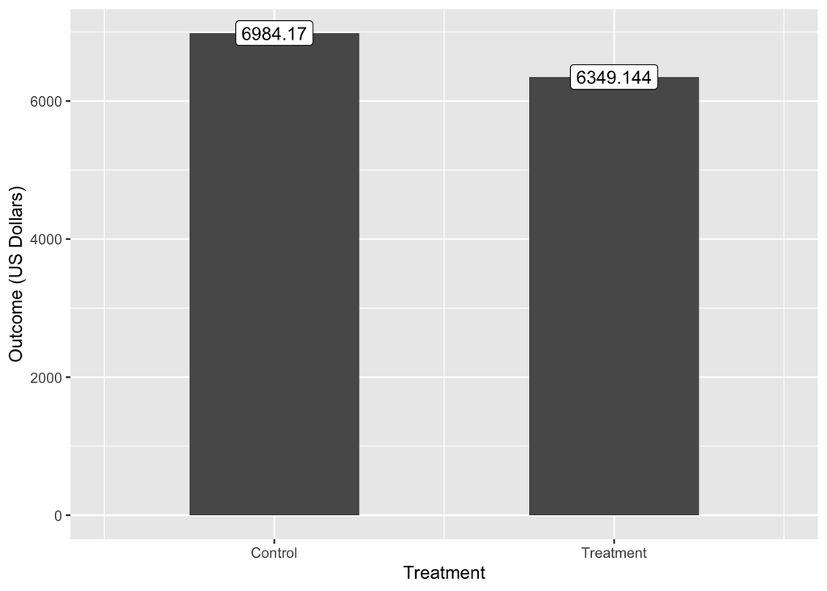

```r
Diff_Mean_df %>%
  ggplot() +
  geom_bar(aes(x = treat, y = Outcome),
           stat = "identity", width = 0.5) +
  geom_label(aes(x = treat, y = Outcome,
                 label = round(Outcome, 3))) +
  labs(x = "Treatment",
       y = "Outcome (US Dollars)") +
  # recode関数を使って0/1をControl/Treatmentに置換する
  scale_x_continuous(breaks = c(0, 1), labels = c("Control", "Treatment")) +
  coord_cartesian(xlim = c(-0.5, 1.5))
```

ちなみに、以上の結果は単回帰分析からも確認可能です (ただし、統計的に有意ではない)。

```r
Raw.Fit1 <- lm(re78 ~ treat, data = Day2_df)
summary(Raw.Fit1)
```

```
##
## Call:
## lm(formula = re78 ~ treat, data = Day2_df)
##
## Residuals:
##    Min     1Q Median     3Q    Max
##  -6984  -6349  -2048   4100  53959
##
## Coefficients:
##             Estimate Std. Error t value Pr(>|t|)
## (Intercept)   6984.2      360.7  19.362   <2e-16
## treat         -635.0      657.1  -0.966    0.334
##
## Residual standard error: 7471 on 612 degrees of freedom
## Multiple R-squared:  0.001524,   Adjusted R-squared:  -0.0001079
## F-statistic: 0.9338 on 1 and 612 DF,  p-value: 0.3342
```

この直感的でない結果は、もしかしたらセレクションバイアスが原因かも知れません。職業訓練の対象が元々非常に所得が低い社会経済的要因を有する被験者になっている可能性があります。たとえば、職業訓練の有無が教育水準や人種、これまでの所得などと関係しているとしましょう。これらの要因は回答者の現在所得にも関係していると考えられます。この場合、処置有無と所得の間には内生性が存在することになります。

本当にそうなのか、共変量のバランスチェックをしてみましょう。もし、処置有無によって回答者の社会経済的要因に大きな差があれば、内生性が存在する証拠になります。ここでは担当教員が作成しました`BalanceR`パッケージを使います。

```r
Blc_Chk <- Day2_df %>%
  BalanceR(group = treat, cov = c(age:educ, white:re75))

Blc_Chk
```

```
##   Covariate   Mean:0     SD:0   Mean:1     SD:1   SB:0-1
## 1       age   28.030   10.787   25.816    7.155   24.190
## 2      educ   10.235    2.855   10.346    2.011   -4.476
## 3     white    0.655    0.476    0.097    0.297  140.799
## 4     black    0.203    0.403    0.843    0.365 -167.083
## 5  hispanic    0.142    0.350    0.059    0.237   27.740
## 6   married    0.513    0.500    0.189    0.393   72.076
## 7  nodegree    0.597    0.491    0.708    0.456  -23.549
## 8      re74 5619.237 6788.751 2095.574 4886.620   59.575
## 9      re75 2466.484 3291.996 1532.055 3219.251   28.700
```

いくつか怪しい箇所があります。たとえば、`treat == 0`の回答者において黒人の割合は約20%ですが、`treat == 1`のそれは約85%です。つまり、黒人ほどより職業訓練を受ける傾向があることを意味します。実際、標準化バイアスは-167という、非常に大きい数値を示しています。この結果を表としてまとめてみましょう。

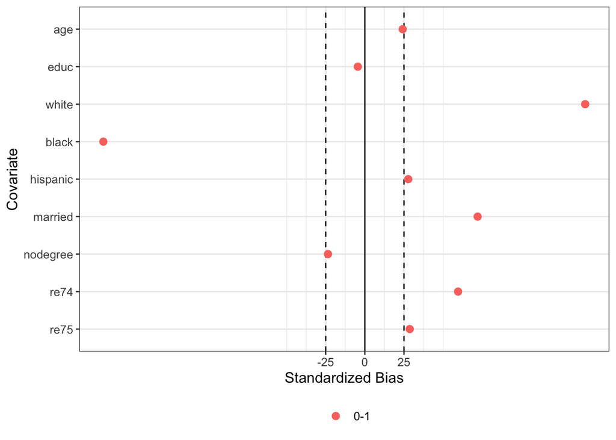

```r
plot(Blc_Chk, vline = 25)
```

かなり緩めの基準である25を採用しても、人種（黒人）、結婚有無、74年の所得のバランスが非常によくありません。内生性があると判断して良いでしょう。以下では様々な方法を使い、この内生性に対処していきたいと思います。

# 内生性への対処

## 重回帰分析

つづいて、重回帰分析もしてみましょう。用いる共変量は年齢、教育水準、黒人ダミー、ヒスパニックダミー、既婚ダミー、学位なしダミー、74・75年の所得です。

```r
Raw.Fit2 <- lm(re78 ~ treat + age + educ + black + hispanic + married +
                   nodegree + re74 + re75, data = Day2_df)
summary(Raw.Fit2) # 処置効果は約1548
```

```
##
## Call:
## lm(formula = re78 ~ treat + age + educ + black + hispanic + married +
##     nodegree + re74 + re75, data = Day2_df)
##
## Residuals:
##    Min     1Q Median     3Q    Max
## -13595  -4894  -1662   3929  54570
##
## Coefficients:
##               Estimate Std. Error t value Pr(>|t|)
## (Intercept)  6.651e+01  2.437e+03   0.027   0.9782
## treat        1.548e+03  7.813e+02   1.982   0.0480
## age          1.298e+01  3.249e+01   0.399   0.6897
## educ         4.039e+02  1.589e+02   2.542   0.0113
## black       -1.241e+03  7.688e+02  -1.614   0.1071
## hispanic     4.989e+02  9.419e+02   0.530   0.5966
## married      4.066e+02  6.955e+02   0.585   0.5590
## nodegree     2.598e+02  8.474e+02   0.307   0.7593
## re74         2.964e-01  5.827e-02   5.086 4.89e-07
## re75         2.315e-01  1.046e-01   2.213   0.0273
##
## Residual standard error: 6948 on 604 degrees of freedom
## Multiple R-squared:  0.1478, Adjusted R-squared:  0.1351
## F-statistic: 11.64 on 9 and 604 DF,  p-value: < 2.2e-16
```

共変量を統制したら処置変数の係数は約1548.244ドルです。先ほどの単回帰分析の結果とは違って、統計的に有意な正の効果が確認されていますね。

## マハラノビス最近傍マッチング

重回帰分析は非常にシンプルで便利な分析方法ですが、いくつかの欠点があります。まず、重回帰分析は変数間の関係（線形結合）および誤差項の分布（正規分布）などを仮定したパラメトリック分析になります。この場合、同じ共変量を持たないケースであっても、勝手に予測を行います。重回帰分析における処置変数の解釈は「他の共変量がすべて同じ」場合の処置効果になります。これは、共変量がすべて同じ場合における（最初に見た）単純差分のようなものです。しかし、「他の共変量がすべて同じ」ケースが存在可能性があります。特に、共変量が多く、連続変数の場合、共変量がすべて同じことは実質あり得ないか、非常に少ないケースに限定されます。一方、マッチングを行うと、「他の共変量がすべて同じ」、または「非常に似ている」ケース間で比較を行います。

ここでは以下の4つの手法を紹介します。

1. マッチング
   - マハラノビス距離最近傍マッチング
   - Coarsened Exact Matching
   - 傾向スコアマッチング
2. 逆確率重み付け

まずは、マハラノビス最近傍マッチングから始めましょう。だいたいのマッチング手法は`MatchIt`パッケージで解決できます。マッチングデータセットを作成する関数は`matchit()`関数であり、使い方は

`matchit(処置変数 ~ 共変量1 + ... + 共変量k, method = "nearest", distance = "mahalanobis")`

のように入力します。`method = "nearest"`は最近傍マッチングを意味し、`distance = "mahalanobis"`はマハラノビス距離を意味します。早速やってみましょう。

```r
MH.Matching <- matchit(treat ~ age + educ + black + hispanic + married +
                           nodegree + re74 + re75, data = Day2_df,
                       method = "nearest", distance = "mahalanobis")
```

バランスチェックは数値的に確認する方法と視覚的にする方法があります。まずは、数値的に確認してみましょう。

```r
# バランスチェック (Numerical)
summary(MH.Matching)
```

```
##
## Call:
## matchit(formula = treat ~ age + educ + black + hispanic + married +
##     nodegree + re74 + re75, data = Day2_df, method = "nearest",
##     distance = "mahalanobis")
##
## Summary of balance for all data:
##          Means Treated Means Control SD Control  Mean Diff   eQQ Med  eQQ Mean
## age            25.8162       28.0303    10.7867    -2.2141    1.0000    3.2649
## educ           10.3459       10.2354     2.8552     0.1105    1.0000    0.7027
## black           0.8432        0.2028     0.4026     0.6404    1.0000    0.6432
## hispanic        0.0595        0.1422     0.3497    -0.0827    0.0000    0.0811
## married         0.1892        0.5128     0.5004    -0.3236    0.0000    0.3243
## nodegree        0.7081        0.5967     0.4911     0.1114    0.0000    0.1135
## re74         2095.5737     5619.2365  6788.7508 -3523.6628 2425.5720 3620.9240
## re75         1532.0553     2466.4844  3291.9962  -934.4291  981.0968 1060.6582
##          eQQ Max
## age        10.00
## educ        4.00
## black       1.00
## hispanic    1.00
## married     1.00
## nodegree    1.00
## re74     9216.50
## re75     6795.01
##
##
## Summary of balance for matched data:
##          Means Treated Means Control SD Control Mean Diff eQQ Med eQQ Mean
## age            25.8162       24.7405     9.9432    1.0757   3.000   3.0432
## educ           10.3459       10.2486     2.2148    0.0973   0.000   0.2378
## black           0.8432        0.4162     0.4943    0.4270   0.000   0.4270
## hispanic        0.0595        0.0595     0.2371    0.0000   0.000   0.0000
## married         0.1892        0.2216     0.4165   -0.0324   0.000   0.0324
## nodegree        0.7081        0.6919     0.4630    0.0162   0.000   0.0162
## re74         2095.5737     2549.2179  4403.2687 -453.6442 346.030 688.5188
## re75         1532.0553     1402.0452  2640.4451  130.0101 171.871 340.3923
##          eQQ Max
## age         9.00
## educ        3.00
```

[output cut: 9 more lines]

```
## age         51.4167 -200.0000   6.7881  10.0000
## educ        11.9599  100.0000  66.1538  25.0000
## black       33.3235  100.0000  33.6134   0.0000
## hispanic   100.0000    0.0000 100.0000 100.0000
## married     89.9786    0.0000  90.0000   0.0000
## nodegree    85.4395    0.0000  85.7143   0.0000
## re74        87.1258   85.7341  80.9850  -3.1297
## re75        86.0867   82.4817  67.9074   0.0000
##
## Sample sizes:
##           Control Treated
## All           429     185
## Matched       185     185
## Unmatched     244       0
## Discarded       0       0
```

つづいて視覚的な方法です。

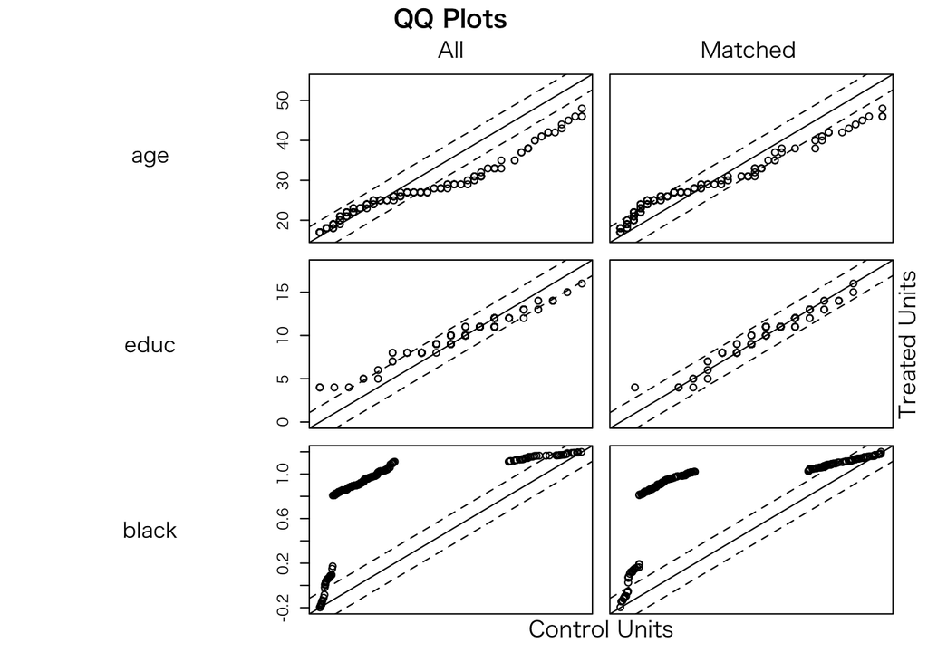

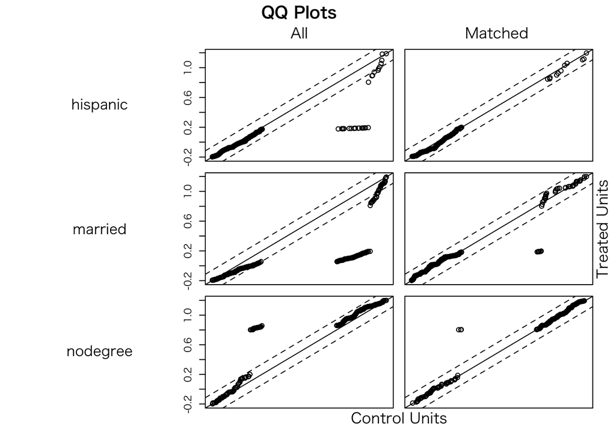

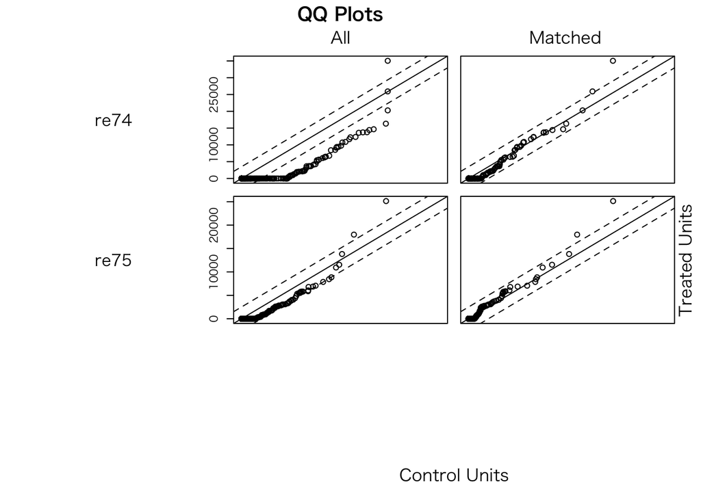

```r
# バランスチェック (Graphical): QQプロットによるバランスチェック
plot(MH.Matching)
```

各ポイントが45度直線上に並ぶのが理想的なバランシングです。バランスが改善されていることが確認できます。

もっと直感的なバランスチェックの方法として`BalanceR`パッケージと同様、標準化バイアスを使う方法です。マッチング前後のバランスを同時に確認するには`cobalt`パッケージの`love.plot`が便利です。

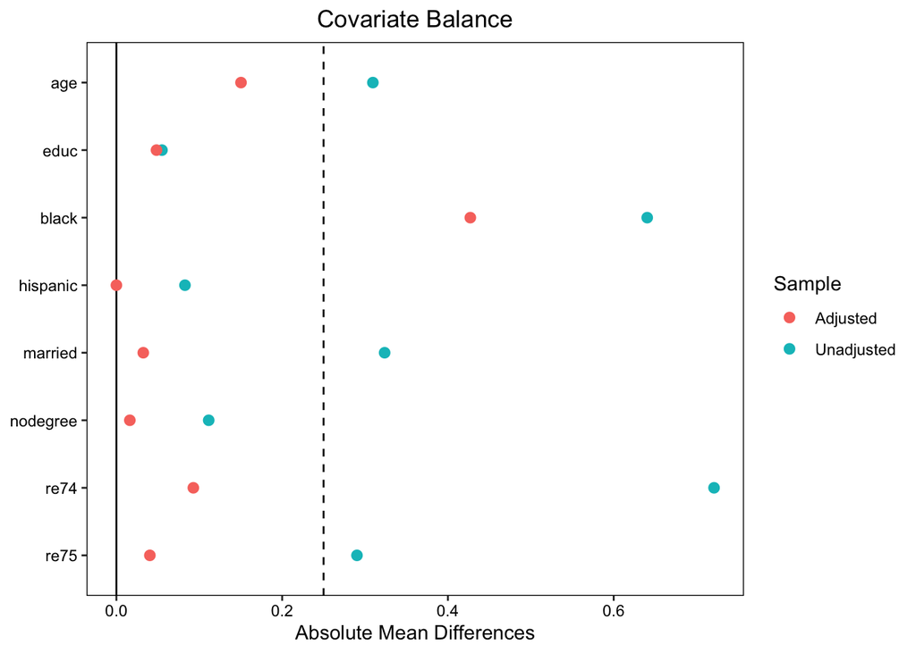

```r
love.plot(MH.Matching, thresholds = 0.25, abs = TRUE)
```

`thresholds`引数は垂直線（破線）の位置、`abs`は標準化バイアスを絶対値で示すことを意味します。マッチング後の標準化バイアス（Adjusted; 赤い点）が0.25より左側に位置している場合、バランスしていると判断できます。他にもマッチング後の標準化バイアスがマッチング前（Unadjusted; 青い点）より改善されるいるか否かも判断できます。今回の例だと、大幅にバランスが改善されました。`black`はまだバランスが取れておりませんが、それでも大幅に改善されていることが分かります。

それではATEを推定してみましょう。推定方法としてはノンパラメトリックな方法とパラメトリック方法がありますが、結果は変わりません。ノンパラメトリックな方法はペアごとの差分を計算し、その平均値を求める方法ですが、マッチング済みのデータに対し、処置変数を結果変数を回帰させることも、結果的には同じことを行うことになります。したがって、もっと簡単なパラメトリック方法でATEを推定します。ノンパラメトリック方法によるATEの推定は本資料の付録を参照してください。

回帰分析を行うためにはデータが必要ですね。つまり、マッチングされないケースをデータから除去する必要があります。したがって、マッチングされた後のデータセットを抽出する必要があります。使う関数は`match.data()`関数です。

```r
# マッチング後データを抽出
MH.Data <- match.data(MH.Matching)
```

マッチングデータが取れたら、その中身を確認してみましょう。

```r
dim(MH.Data)
```

```
## [1] 370  14
```

データのサイズは370行14列です。この370行には意味があります。それは処置群の大きさの2倍という点です。多くの場合、マッチングから計算される処置効果はATEではなく、ATTです。したがって、処置群のデータを100%活用し、統制群から共変量が最も近いケースを抽出&マッチングすることになります。だから、マッチング後のサンプルサイズは処置群のサイズの2倍になります。

それでは職業訓練のATTを推定します。方法は簡単です。このマッチング後のデータを用い、単回帰分析を行うのみです。

```r
# 処置効果の確認 (Model-Based)
MH.Fit <- lm(re78 ~ treat, data = MH.Data)

summary(MH.Fit)
```

```
##
## Call:
## lm(formula = re78 ~ treat, data = MH.Data)
##
## Residuals:
##    Min     1Q Median     3Q    Max
##  -6349  -5449  -2185   3162  53959
##
## Coefficients:
##             Estimate Std. Error t value Pr(>|t|)
## (Intercept)   5448.7      521.1  10.456   <2e-16
## treat          900.5      737.0   1.222    0.223
##
## Residual standard error: 7088 on 368 degrees of freedom
## Multiple R-squared:  0.004041,   Adjusted R-squared:  0.001334
## F-statistic: 1.493 on 1 and 368 DF,  p-value: 0.2225
```

処置効果は約900.478ドルであり、付録にあるノンパラメトリック推定値と一致していることが分かります。今回の結果は重回帰分析よりも推定値が低めであり、統計的に有意に職業訓練の効果があったとは言えないという結果が得られましたね。

ちなみに、`MatchIt`パッケージを使った最近傍マッチングのの結果は行う度に変化することがあります。なぜなら、`MatchIt`パッケージを使った最近傍マッチングの場合、処置群 (統制群)から一つのケースを選択し、最も近い統制群 (処置群)とマッチングさせます。マッチングされたケースは次のステップからはマッチング対象から除外されます。また、1:1マッチングの場合、同距離に複数のマッチング対象があると、ランダムに1つのみを選択します。最近傍マッチングを用いる際は、複数推定を行い、推定が安定するかを確認し、不安定な場合は他の手法を使うか、k-最近傍マッチングなどを使ってみましょう。

## Coarsened Exact Matching

CEMはマハラノビス最近傍マッチング同様、`matchit()`関数を使います。ただし、`cem`パッケージをインストールしておく必要があります。まず、Exact Matching類の手法は距離を図る必要がないので、`distance`引数は不要です。`method = ...`引数を`"nearest"` (最近傍)から`"cem"`に替えるだけです。

マッチングをしたら`match.data()`でマッチングされたデータを抽出します。

```r
CEM.Matching <- matchit(treat ~ age + educ + black + hispanic + married +
                            nodegree + re74 + re75, data = Day2_df,
                       method = "cem")
```

```
##
## Using 'treat'='1' as baseline group
```

```r
summary(CEM.Matching)
```

```
##
## Call:
## matchit(formula = treat ~ age + educ + black + hispanic + married +
##     nodegree + re74 + re75, data = Day2_df, method = "cem")
##
## Summary of balance for all data:
##          Means Treated Means Control SD Control  Mean Diff   eQQ Med  eQQ Mean
## distance        0.5774        0.1822     0.2295     0.3952    0.5176    0.3955
## age            25.8162       28.0303    10.7867    -2.2141    1.0000    3.2649
## educ           10.3459       10.2354     2.8552     0.1105    1.0000    0.7027
## black           0.8432        0.2028     0.4026     0.6404    1.0000    0.6432
## hispanic        0.0595        0.1422     0.3497    -0.0827    0.0000    0.0811
## married         0.1892        0.5128     0.5004    -0.3236    0.0000    0.3243
## nodegree        0.7081        0.5967     0.4911     0.1114    0.0000    0.1135
## re74         2095.5737     5619.2365  6788.7508 -3523.6628 2425.5720 3620.9240
## re75         1532.0553     2466.4844  3291.9962  -934.4291  981.0968 1060.6582
##            eQQ Max
## distance    0.5966
## age        10.0000
## educ        4.0000
## black       1.0000
## hispanic    1.0000
## married     1.0000
## nodegree    1.0000
## re74     9216.5000
## re75     6795.0100
##
##
## Summary of balance for matched data:
##          Means Treated Means Control SD Control Mean Diff eQQ Med eQQ Mean
## distance        0.6044        0.6062     0.2013   -0.0018   0.039   0.1579
## age            21.5441       21.1781     5.7469    0.3660   2.000   2.1324
## educ           10.2941       10.3827     2.0128   -0.0886   1.000   0.6471
## black           0.8676        0.8676     0.3411    0.0000   0.000   0.2647
## hispanic        0.0588        0.0588     0.2368    0.0000   0.000   0.0441
## married         0.0441        0.0441     0.2067    0.0000   0.000   0.0294
## nodegree        0.6176        0.6176     0.4891    0.0000   0.000   0.1324
## re74          456.1345      622.8740  1179.3680 -166.7395   0.000 308.6606
## re75          350.6728      520.7135   980.3655 -170.0407   0.000 191.2399
##            eQQ Max
```

[output cut: 13 more lines]

```
## age         83.4693 -100.0000  34.6879  0.0000
## educ        19.8185    0.0000   7.9186 50.0000
## black      100.0000  100.0000  58.8482  0.0000
## hispanic   100.0000    0.0000  45.5882  0.0000
## married    100.0000    0.0000  90.9314  0.0000
## nodegree   100.0000    0.0000 -16.5966  0.0000
## re74        95.2680  100.0000  91.4756 74.2171
## re75        81.8027  100.0000  81.9697 87.7188
##
## Sample sizes:
##           Control Treated
## All           429     185
## Matched        78      68
## Unmatched     351     117
## Discarded       0       0
```

CEMの場合、マッチングされないブロックは捨てられるため、マハラノビス距離最近傍マッチングよりもサンプルサイズが小さくなります。また、処置群と統制群のサンプルサイズも不均衡になります。マッチング結果を見ると、処置群からは68ケース、統制群からは78サンプルのみ残ることになりました。

つづいて、`cobalt::love.plot()`を使用して、バランスチェックを行います。

```
## Note: 's.d.denom' not specified; assuming pooled.
```

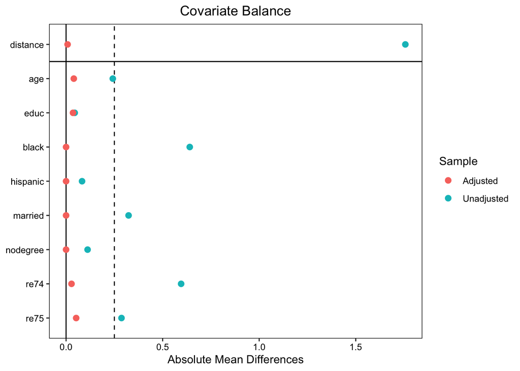

```r
love.plot(CEM.Matching, thresholds = 0.25, abs = TRUE)
```

CEMの場合、マハラノビス距離最近傍マッチングよりもバランスが大きく改善されたことが分かります。その理由は簡単です。最近傍マッチングの場合、最も近いケースであれば、どれほど離れていてもマッチングされます。一方、CEMは正確マッチングの一種であるため、ある程度離れているケースを捨ててしまうからです。結局は共変量が非常に近いケースのみを残すことになります。

それでは、`match.data()`関数を使ってマッチング後のデータを抽出してみましょう。

```r
CEM.Data <- match.data(CEM.Matching)
```

```r
head(CEM.Data)
```

```
##    treat age educ   race white black hispanic married nodegree re74 re75
## 2      1  22    9 hispan     0     0        1       0        1    0    0
## 6      1  22    9  black     0     1        0       0        1    0    0
## 7      1  23   12  black     0     1        0       0        0    0    0
## 9      1  22   16  black     0     1        0       0        0    0    0
## 11     1  19    9  black     0     1        0       0        1    0    0
## 12     1  21   13  black     0     1        0       0        0    0    0
##         re78  distance weights subclass
## 2   3595.894 0.2246342       1       65
## 6   4056.494 0.6990699       1       68
## 7      0.000 0.6536843       1      110
## 9   2164.022 0.7798382       1      131
## 11  8173.908 0.6890200       1       12
## 12 17094.640 0.6824440       1      127
```

処置効果の推定は重み付き回帰分析 (WLS)で行います。既存の`lm()`関数に`weight = ...`引数を追加し、データ内の重み列をしてするだけです。

```r
# 処置効果の確認
# weight = Wが追加されていることを確認
CEM.Fit <- lm(re78 ~ treat, data = CEM.Data,
              weights = weights)

# 処置効果の確認
summary(CEM.Fit)
```

```
##
## Call:
## lm(formula = re78 ~ treat, data = CEM.Data, weights = weights)
##
## Weighted Residuals:
##    Min     1Q Median     3Q    Max
## -11694  -4599  -1449   2532  28224
##
## Coefficients:
##             Estimate Std. Error t value Pr(>|t|)
## (Intercept)   5459.4      682.9   7.995 3.85e-13
## treat          415.4     1000.6   0.415    0.679
##
## Residual standard error: 6031 on 144 degrees of freedom
## Multiple R-squared:  0.001196,   Adjusted R-squared:  -0.00574
## F-statistic: 0.1724 on 1 and 144 DF,  p-value: 0.6786
```

今回、処置効果の推定値は約415.449ドルです。

## 傾向スコアマッチング

傾向スコアマッチングも、これまでのコマンドとほぼ同じです。マハラノビス最近傍マッチングのコマンドから`distance = ...`引数を抜けば、傾向スコアマッチングができます[^2]。また、`replace`引数に`TRUE`を指定します。これは一度マッチングしたケースを捨てずに、次のマッチングにも使うことを意味します。デフォルトは`FALSE`となっており、この場合、一度マッチングされたケースは二度とマッチングされません。したがって、`replace = TRUE`を指定した方が共変量バランスがより改善されます。

```r
PS.Matching <- matchit(treat ~ age + educ + black + hispanic + married +
                           nodegree + re74 + re75, data = Day2_df,
                       method = "nearest", replace = TRUE)
```

処置効果の推定の前に、バランスが取れているかどうかを確認してみましょう。これまではQQプロットのみでバランスチェックをしましたが、今回はヒストグラムとJitterプロットで確認します。

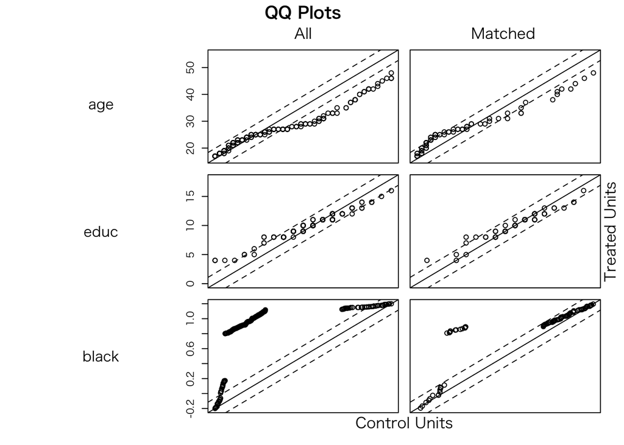

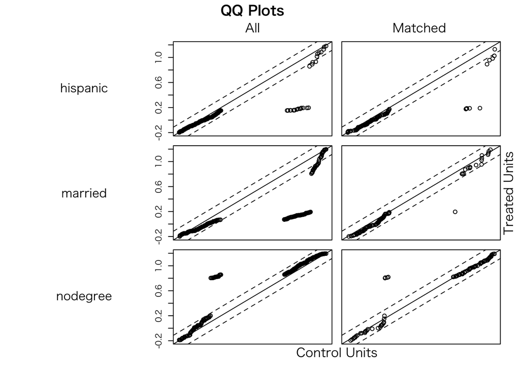

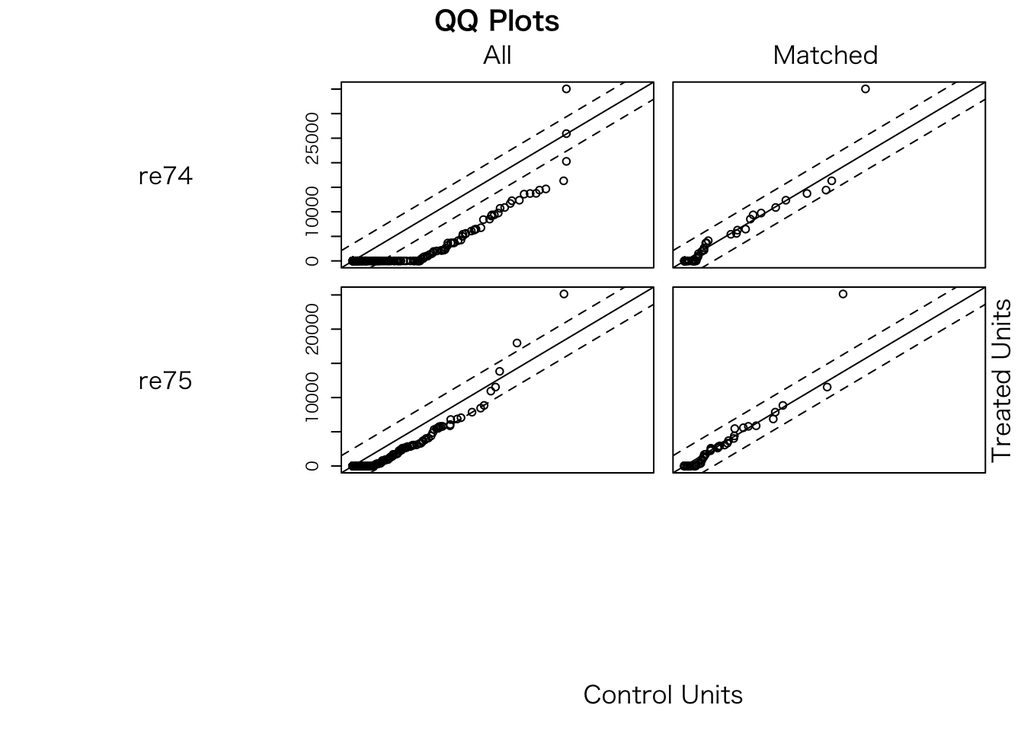

```r
# 1. QQプロットによるバランスチェック
plot(PS.Matching)
```

QQプロットを見ると、バランスが多少改善されていることが分かります。

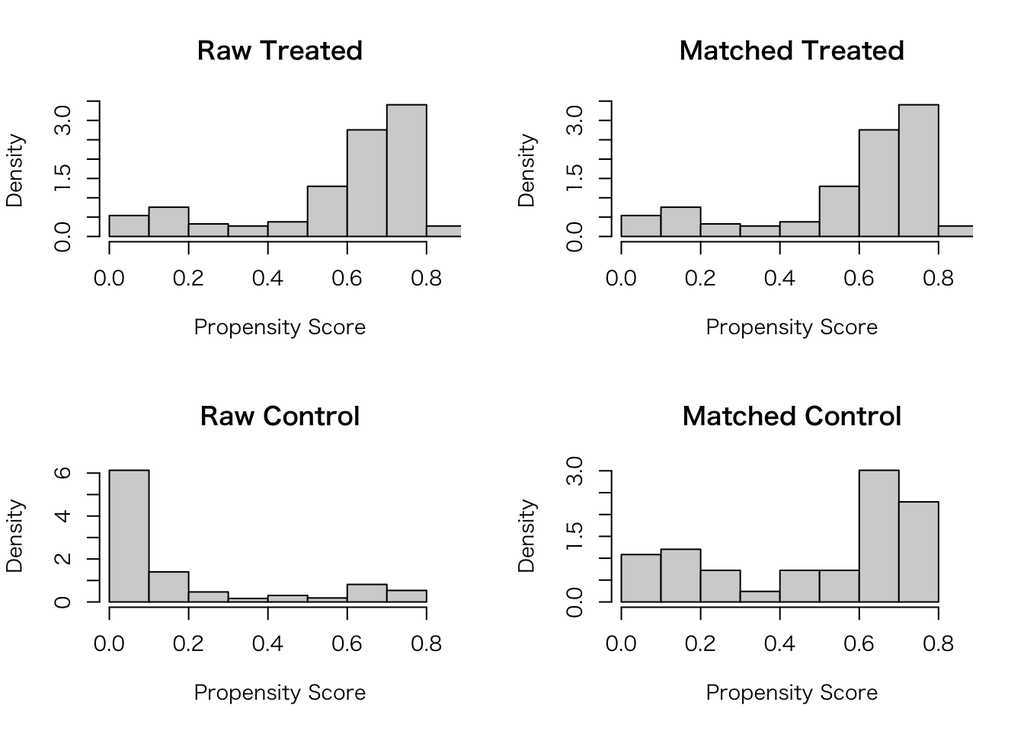

```r
# 2. ヒストグラムによるバランスチェック
plot(PS.Matching, type = "hist")
```

ヒストグラムからもバランスが改善されたことが確認できますね。出来れば、ヒストグラムを重ねて比較したいんですが、残念です。あとでオーバーラップされたヒストグラムの作成方法について解説します。

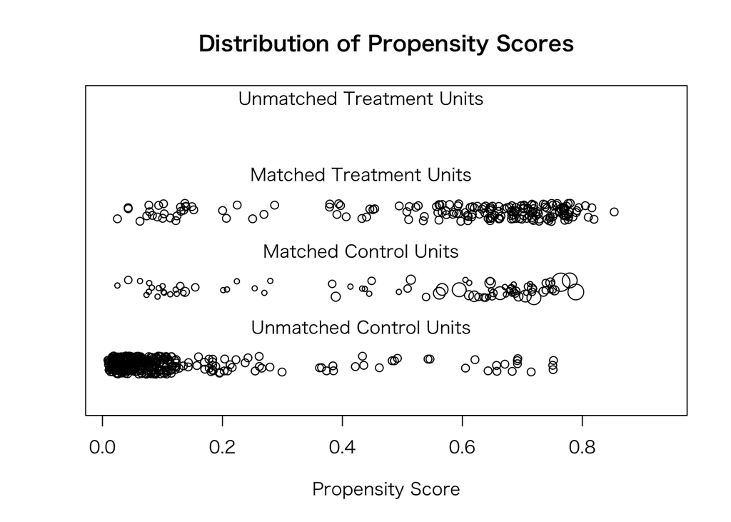

```
## [1] "To identify the units, use first mouse button; to stop, use second."
```

```
## integer(0)
```

```r
# 3. 散布図によるバランスチェック
par(mfrow = c(1, 1))
plot(PS.Matching, type = "jitter")
```

散布図をみると、傾向スコア ($e$)が小さいケースがマッチングから除外されたことが分かります。実際、処置群には傾向スコアが小さいケースが非常に少ないため、これは妥当な結果でしょう。

むろん、おなじみの`cobalt::love.plot()`でもバランスチェックができます。

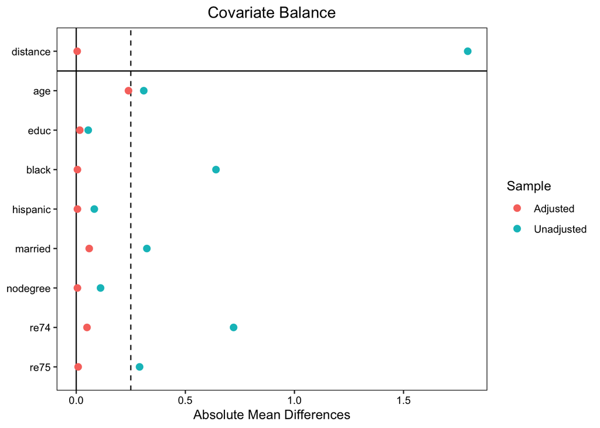

```r
love.plot(PS.Matching, thresholds = 0.25, abs = TRUE)
```

それでは、ATT推定のためにマッチング後のデータを抽出します。

```r
# 傾向スコアマッチング後のデータセットを抽出
PS.Data <- match.data(PS.Matching)
```

傾向スコアを用いたATTをの推定もこれまでと同様、回帰分析を用います。普通の回帰分析ですが、用いるデータは傾向スコアでマッチングされたデータのみになります。ただし、今回は重み付け変数である`weights`を指定する必要があります。なぜなら、統制群から1つのケースが何回もマッチングされる可能性があるからです。統制群のあるケースが数回マッチングされても`PS.Data`にそのケースは1つしかありません。この場合は重みをより高く付ける必要があります。幸い、`MatchIt`パッケージはその重みの自動的に計算してくれます。具体的にはCEMと同様、`weights`変数が`PS.Data`に追加されます。

```r
# 処置効果の推定
PS.Fit <- lm(re78 ~ treat, data = PS.Data, weights = weights)

summary(PS.Fit)
```

```
##
## Call:
## lm(formula = re78 ~ treat, data = PS.Data, weights = weights)
##
## Weighted Residuals:
##    Min     1Q Median     3Q    Max
## -10333  -5076  -1856   3177  53959
##
## Coefficients:
##             Estimate Std. Error t value Pr(>|t|)
## (Intercept)   4487.1      792.4   5.663 3.86e-08
## treat         1862.1      953.7   1.952   0.0519
##
## Residual standard error: 7219 on 266 degrees of freedom
## Multiple R-squared:  0.01413,    Adjusted R-squared:  0.01042
## F-statistic: 3.812 on 1 and 266 DF,  p-value: 0.05194
```

処置効果は約1862.055ドルでした。

ちなみに、講義スライド24ページ目の例を`MatchIt`パッケージを使うと以下のようなコードになります。

```r
# 講義スライドのデータ
PS.df2 <- read.csv("Day2_Data2.csv")

Example_Mat <- matchit(Treat ~ Age + Edu,
        data = PS.df2, method = "nearest", replace = TRUE)

Example_Data <- match.data(Example_Mat)

Example_Fit <- lm(Outcome ~ Treat, data = Example_Data, weights = weights)

summary(Example_Fit)
```

```
##
## Call:
## lm(formula = Outcome ~ Treat, data = Example_Data, weights = weights)
##
## Weighted Residuals:
##     Min      1Q  Median      3Q     Max
## -3.0384 -0.9495 -0.6714  1.2727  3.9539
##
## Coefficients:
##             Estimate Std. Error t value Pr(>|t|)
## (Intercept)   4.9091     0.8297   5.917 2.83e-05
## Treat         1.8182     1.0314   1.763   0.0983
##
## Residual standard error: 2.032 on 15 degrees of freedom
## Multiple R-squared:  0.1716, Adjusted R-squared:  0.1164
## F-statistic: 3.108 on 1 and 15 DF,  p-value: 0.09829
```

手計算から得られた結果と一致することが分かります。

## IPW推定量

最後にATTでなく、ATEが推定の対象となるIPW推定量を計算してみましょう。`WeightIt`パッケージを使用すれば便利ですが、ここではあえて使わずにIPW推定量を計算してみましょう。こうすることでIPWが具体的にどのような仕組みで推定されるかが理解できるはずです。一通りの推定が終わりましたら`WeightIt`パッケージの使い方も紹介します。

### パッケージを使わない方法

まずは、傾向スコアの算出ですが、ここではロジスティック回帰分析で傾向スコアを計算します[^3]。

```r
# Logitで傾向スコアを推定
PS <- glm(treat ~ age + educ + black + hispanic + married + nodegree +
              re74 + re75, data = Day2_df,
          family = binomial("logit"))
```

続いて、既存のデータフレームに傾向スコアが格納された列を追加します。まず、既存の`lalonde`データセットを`Matching.df`という名前で複製します。

新しいデータフレームに`PS`という列を作成し、ここに傾向スコアを格納します。傾向スコアはロジスティック回帰分析のオブジェクトに`$fitted.values`を加えるだけで抽出できます。

```r
# lalondeデータフレームを複製
Matching.df <- Day2_df

# 傾向スコア推定値をデータフレーム内に格納
Matching.df$PS <- PS$fitted.values
```

次は、各ケースの重みを計算し、`W`という新しい列として追加します。傾向スコアは、もしケースが処置群 (`treat == 1`)なら、$\frac{1}{e}$を、統制群 (`treat == 0`)なら$\frac{1}{(1-e)}$となります。

```r
# 重み変数を作成
## ケースが処置群なら、重み = 傾向スコアの逆数
## ケースが統制群あら、重み = (1 - 傾向スコア)の逆数
Matching.df <- Matching.df %>%
    mutate(W = ifelse(treat == 1, (1 / PS),
                      (1 / (1 - PS))))
```

以上のコードは以下のコードでも同じく作動します。

```r
Matching.df <- Matching.df %>%
    mutate(W = treat * (1 / PS) + (1 - treat) * (1 / (1 - PS)))
```

むろん、`dplyr`の`mutate()`を使わずに、以下のように入力しても重み変数は作成可能である。

```r
Matching.df$W <- ifelse(Matching.df$treat == 1,
                        1 / Matching.df$PS,
                        1 / (1 - Matching.df$PS))
```

最後に処置効果の推定です。CEMの時と同じやり方です。`weight = ...`引数を追加するだけです。

```r
# 回帰分析にweight = ...を指定するだけ
IPW.Fit <- lm(re78 ~ treat, data = Matching.df,
              weights = W)

summary(IPW.Fit)
```

```
##
## Call:
## lm(formula = re78 ~ treat, data = Matching.df, weights = W)
##
## Weighted Residuals:
##    Min     1Q Median     3Q    Max
## -42083  -6606  -2284   4979  77674
##
## Coefficients:
##             Estimate Std. Error t value Pr(>|t|)
## (Intercept)   6422.8      397.4  16.161   <2e-16
## treat          224.7      577.7   0.389    0.697
##
## Residual standard error: 9864 on 612 degrees of freedom
## Multiple R-squared:  0.0002471,  Adjusted R-squared:  -0.001386
## F-statistic: 0.1513 on 1 and 612 DF,  p-value: 0.6975
```

推定された処置効果は約224.676ドルです。

### `WeightIt`パッケージを使用した場合

それでは`WeightIt`パッケージを使ってみましょう。これまで使ってきました`MatchIt`パッケージや傾向スコア算出のための`glm()`関数と使い方が非常に似ています。まず、第一引数として処置変数を結果変数、処置有無に影響を与えると考えられる共変量を説明変数とした数式オブジェクト（formulaクラス）を指定します。続いて、データ（`data`）、IPW算出の方法（`method`）、推定の対象（`estimand`）を指定します。データは`data = Day2_df`とし、傾向スコアからIPWを算出するため`method = "ps"`を指定、最後にATE推定のために`estimand = "ATE"`を指定します。ATTあるいはATCを計算する場合は`"ATE"`を適宜変更してください。また、IPW算出のために今回は傾向スコアを使いましたが、「処置を受ける確率」が計算できるなら何でも良いです。たとえば、Imai and Ratkovic (2014)[^4]が推奨しているCovariate Balancing Propensity Score (CBPS) を使用する場合は`"ps"`の代わりに`"cbps"`を、複数の推定を組み合わせるスーパーラーニングをする場合は`"super"`[^5]などが使えます。他にもエントロピーバランシングなど様々なオプションが提供されています。ここでは、先程の手法との比較のために、デフォルトの`"ps"`を使います。

```r
Weighted_Data <- weightit(treat ~ age + educ + black + hispanic + married +
                            nodegree + re74 + re75, data = Day2_df,
                          method = "ps", estimand = "ATE")
```

`WeightIt`パッケージの便利なところは`cobal::love.plot()`によるバランスチェックが簡単ということです。実際にやってみましょう。

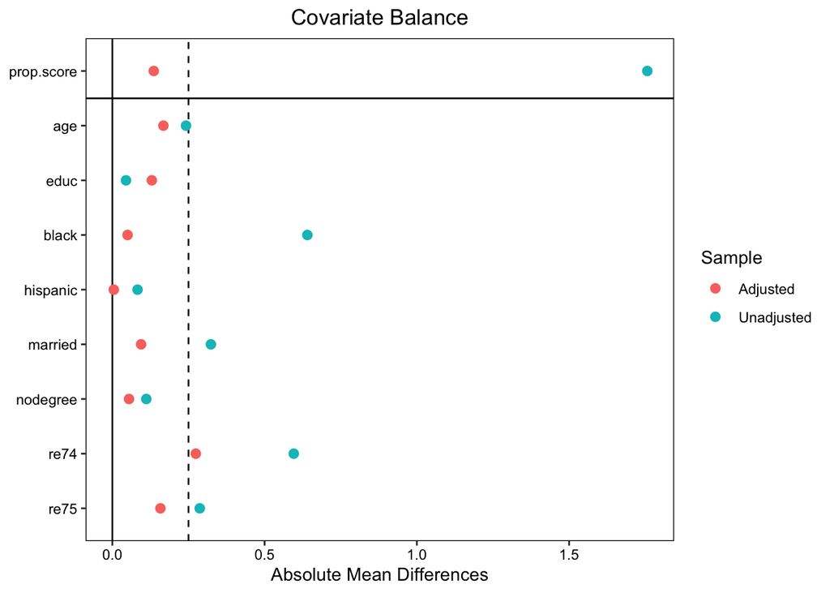

```r
love.plot(Weighted_Data, thresholds = 0.25, abs = TRUE)
```

最後にIPW推定量を計算してみましょう。ここは先ほどの面倒くさい方法と同じですが、重み付け変数は`weightit()`関数から得られたオブジェクト（`Weighted_Data`）の`weights`列を使用します。推定ができたら結果を出力します。

```r
IPW_Result <- lm(re78 ~ treat, data = Day2_df,
                 weights = Weighted_Data$weights)

summary(IPW_Result)
```

```
##
## Call:
## lm(formula = re78 ~ treat, data = Day2_df, weights = Weighted_Data$weights)
##
## Weighted Residuals:
##    Min     1Q Median     3Q    Max
## -42083  -6606  -2284   4979  77674
##
## Coefficients:
##             Estimate Std. Error t value Pr(>|t|)
## (Intercept)   6422.8      397.4  16.161   <2e-16
## treat          224.7      577.7   0.389    0.697
##
## Residual standard error: 9864 on 612 degrees of freedom
## Multiple R-squared:  0.0002471,  Adjusted R-squared:  -0.001386
## F-statistic: 0.1513 on 1 and 612 DF,  p-value: 0.6975
```

224.7という結果が得られましたが、これは`WeightIt`パッケージを使わなかった結果と完全に一致しますね。

# 付録

## ノンパラメトリック推定

ここではマハラノビス最近傍マッチングの例を使って、ATTを推定してみましょう。まずは、処置群の潜在的結果を統制群から割り当てて差分を算出し、その平均値を求るというのがノンパラメトリックな推定方法です。以下のコードが理解できるようになれば、他の最近傍マッチング（傾向スコアマッチングなど）も外部パッケージを使わずに計算できるようになります。

各処置群がどのケースとマッチングされたかはマッチングのオブジェクト名の後に`$match.matrix`を付けることで抽出できます。ちょっとやってみましょう。

```r
# 全部表示させると長くなんるので、最初の6行まで確認
head(MH.Matching$match.matrix)
```

```
##   1
## 1 "553"
## 2 "526"
## 3 "377"
## 4 "367"
## 5 "357"
## 6 "455"
```

左が処置群、右が統制群ですね。それぞれケースのIDを抽出しましょう。

```r
# MH.Matching$match.matrixは1列の行列です。
# 処置群IDは行の名前として格納され、統制群IDは1列目に入っています。
MH.Treat   <- as.vector(row.names(MH.Matching$match.matrix))
MH.Control <- as.vector(MH.Matching$match.matrix[, 1])

# 中身を確認
print(MH.Treat)
```

```
##   [1] "1"   "2"   "3"   "4"   "5"   "6"   "7"   "8"   "9"   "10"  "11"  "12"
##  [13] "13"  "14"  "15"  "16"  "17"  "18"  "19"  "20"  "21"  "22"  "23"  "24"
##  [25] "25"  "26"  "27"  "28"  "29"  "30"  "31"  "32"  "33"  "34"  "35"  "36"
##  [37] "37"  "38"  "39"  "40"  "41"  "42"  "43"  "44"  "45"  "46"  "47"  "48"
##  [49] "49"  "50"  "51"  "52"  "53"  "54"  "55"  "56"  "57"  "58"  "59"  "60"
##  [61] "61"  "62"  "63"  "64"  "65"  "66"  "67"  "68"  "69"  "70"  "71"  "72"
##  [73] "73"  "74"  "75"  "76"  "77"  "78"  "79"  "80"  "81"  "82"  "83"  "84"
##  [85] "85"  "86"  "87"  "88"  "89"  "90"  "91"  "92"  "93"  "94"  "95"  "96"
##  [97] "97"  "98"  "99"  "100" "101" "102" "103" "104" "105" "106" "107" "108"
## [109] "109" "110" "111" "112" "113" "114" "115" "116" "117" "118" "119" "120"
## [121] "121" "122" "123" "124" "125" "126" "127" "128" "129" "130" "131" "132"
## [133] "133" "134" "135" "136" "137" "138" "139" "140" "141" "142" "143" "144"
## [145] "145" "146" "147" "148" "149" "150" "151" "152" "153" "154" "155" "156"
## [157] "157" "158" "159" "160" "161" "162" "163" "164" "165" "166" "167" "168"
## [169] "169" "170" "171" "172" "173" "174" "175" "176" "177" "178" "179" "180"
## [181] "181" "182" "183" "184" "185"
```

```r
print(MH.Control)
```

```
##   [1] "553" "526" "377" "367" "357" "455" "391" "506" "590" "578" "540" "566"
##  [13] "561" "458" "437" "467" "452" "470" "601" "430" "574" "405" "409" "459"
##  [25] "527" "563" "559" "384" "586" "465" "474" "572" "544" "571" "525" "595"
##  [37] "518" "516" "606" "462" "522" "422" "453" "576" "614" "493" "555" "562"
##  [49] "476" "419" "607" "560" "466" "374" "567" "577" "457" "613" "565" "538"
##  [61] "583" "385" "382" "372" "541" "438" "403" "432" "539" "454" "594" "427"
##  [73] "599" "537" "415" "610" "568" "463" "585" "573" "521" "414" "546" "556"
##  [85] "511" "279" "450" "542" "396" "587" "593" "536" "369" "558" "411" "592"
##  [97] "393" "597" "596" "524" "582" "508" "608" "557" "390" "604" "609" "451"
## [109] "400" "502" "530" "551" "376" "416" "445" "507" "500" "406" "443" "501"
## [121] "584" "552" "446" "353" "475" "478" "520" "333" "512" "499" "436" "515"
## [133] "399" "278" "352" "365" "420" "394" "339" "362" "358" "284" "510" "589"
## [145] "297" "364" "327" "591" "381" "368" "303" "295" "441" "322" "423" "344"
## [157] "356" "288" "370" "342" "325" "413" "212" "209" "273" "312" "387" "319"
## [169] "259" "271" "274" "282" "335" "343" "281" "205" "280" "224" "257" "202"
## [181] "244" "208" "191" "190" "186"
```

次は、元の`lalonde`データから処置群と統制群の結果変数 (`re78`)を抽出し、`MH.Matched.df`というデータフレームとしてまとめます。続いて、各ケースのITEを計算します。

```r
MH.Matched.df <- data.frame(
    Treat.ID   = MH.Treat,
    Control.ID = MH.Control,
    Treat.Y    = lalonde[MH.Treat,]$re78,
    Control.Y  = lalonde[MH.Control,]$re78
)

MH.Matched.df <- MH.Matched.df %>%
    mutate(ITE = Treat.Y - Control.Y)

head(MH.Matched.df)
```

```
##   Treat.ID Control.ID    Treat.Y Control.Y       ITE
## 1        1        553  9930.0460     0.000  9930.046
## 2        2        526  3595.8940 12618.310 -9022.416
## 3        3        377 24909.4500  4975.505 19933.945
## 4        4        367  7506.1460 12489.750 -4983.604
## 5        5        357   289.7899  9206.237 -8916.447
## 6        6        455  4056.4940  1725.985  2330.509
```

1行目を見ると1は553とマッチングされ、それぞれの結果変数は9930.046ドル、0ドルです。その差分がITEであり、9930.046ドルですね。

これらITEの平均値がATTとなります。早速計算してみましょう。

```r
MH.ATT <- mean(MH.Matched.df$ITE)

print(MH.ATT)
```

```
## [1] 900.4782
```

ATTは約900.478ドルでした。回帰分析でやった結果と一致しますね。大人しく回帰分析でやりましょう。

## バランスチェック

これまでは主にQ-Q Plotを用いたバランスチェックを紹介しましたが、`MatchIt`パッケージは標準化差分/標準化バイアスのバランスチェックにも対応します。やり方としては、

```r
X <- matchit(...)
X.Blc <- summary(X, standardize = TRUE)

plot(X, interactive = FALSE)
```

です。たとえば、傾向スコアマッチングの例だと、

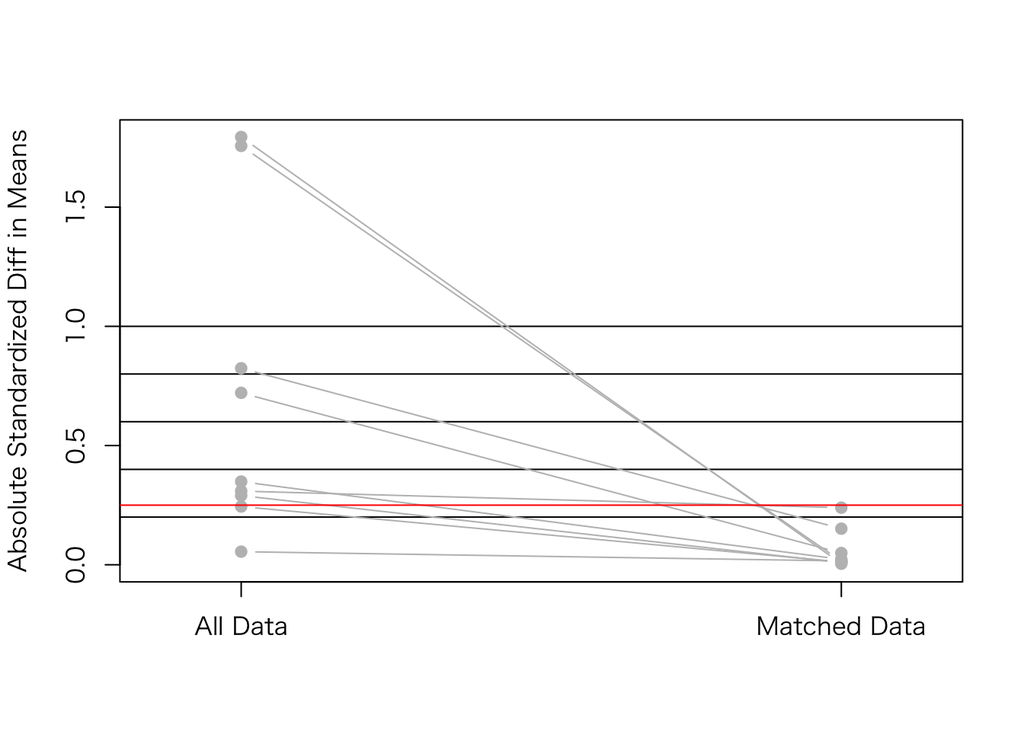

```r
PS.Blc <- summary(PS.Matching, standardize = TRUE)

plot(PS.Blc, interactive = FALSE)
abline(h = 0.25, col = "red")
```

もっと分かりやすい図がほしければ、これまで何回か使ってきました`cobalt`パッケージがおすすめです。

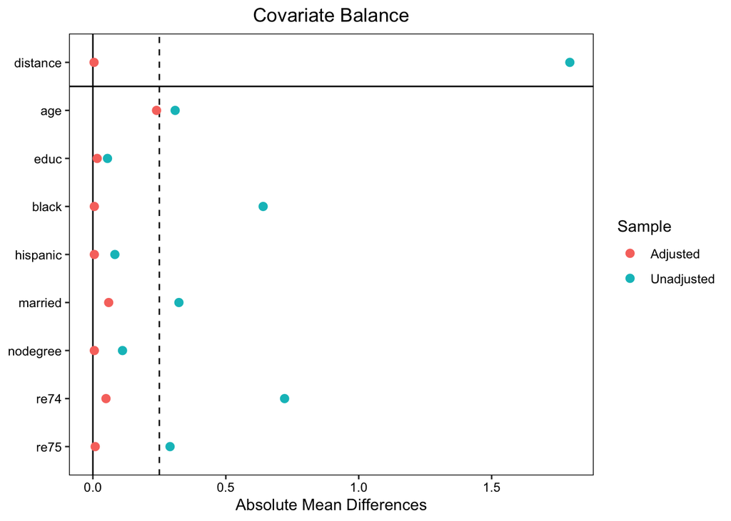

```r
library(cobalt)

love.plot(PS.Matching, threshold = 0.25, abs = TRUE)
```

他にも傾向スコアをマッチング前後に分けてヒストグラム化することもいいでしょう。

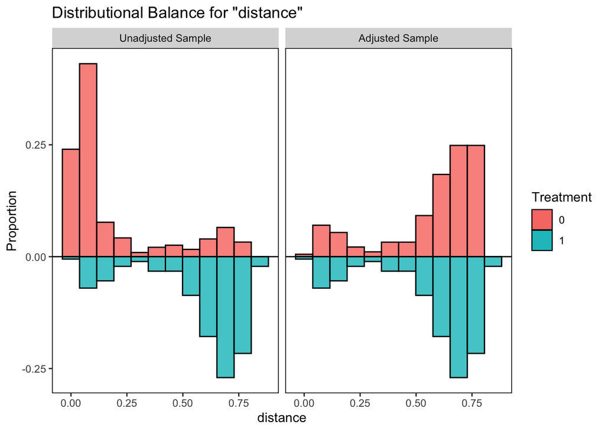

```r
bal.plot(PS.Matching, var.name = "distance", which = "both",
         type = "histogram", mirror = TRUE)
```

## 複数の手法を用いた場合、推定値の比較

これまでの推定値を同時に示す図を作ってみましょう。そのためには各推定結果のオブジェクトから処置変数の係数を抽出する必要があります。たとえば、重回帰分析によるATEの推定結果は`Raw.Fit2`に格納されています。`lm()`や`glm()`関数で行った推定結果から係数のみを抽出する関数は`coef()`です。

```r
coef(Raw.Fit2)
```

```
##   (Intercept)         treat           age          educ         black
##    66.5145197  1548.2438020    12.9776337   403.9412309 -1240.6440820
##      hispanic       married      nodegree          re74          re75
##   498.8968650   406.6208454   259.8173680     0.2963774     0.2315259
```

各係数の推定値がベクトルとして表示されます。ここで処置変数（`treat`）の係数はベクトルの2番目の要素であるため、`coef(Raw.Fit2)[2]`で抽出できます。他の手法による推定についても同じです。なぜなら、これまで処置変数を1番目の説明変数として使ってきたからです。

一方、標準誤差の抽出はちょっと面倒くさいです。いくつかの方法がありますが、ここでは`summary(オブジェクト名)$coef`を使います。推定結果を出力する`summary()`関数の`coef`要素を抽出すると以下のようなデータフレームが抽出されます。

```r
summary(Raw.Fit2)$coef
```

```
##                  Estimate   Std. Error     t value     Pr(>|t|)
## (Intercept)    66.5145197 2.436746e+03  0.02729645 9.782323e-01
## treat        1548.2438020 7.812793e+02  1.98167775 4.796824e-02
## age            12.9776337 3.248891e+01  0.39944816 6.897042e-01
## educ          403.9412309 1.589062e+02  2.54200990 1.127038e-02
## black       -1240.6440820 7.687644e+02 -1.61381572 1.070897e-01
## hispanic      498.8968650 9.419425e+02  0.52964681 5.965515e-01
## married       406.6208454 6.954723e+02  0.58466862 5.589889e-01
## nodegree      259.8173680 8.474421e+02  0.30659013 7.592610e-01
## re74            0.2963774 5.827264e-02  5.08604832 4.885775e-07
## re75            0.2315259 1.046199e-01  2.21301982 2.726937e-02
```

ここで、`treat`の標準誤差は2行2列目に格納されていることが分かります。したがって、`treat`標準誤差は`summary(Raw.Fit2)$coef[2, 2]`で抽出できます。他にも`summary(Raw.Fit2)`から抽出できる要素は色々あります。興味のある方は`str(summary(Raw.Fit2))`で確認してみてください。

```r
Comparison.df <- data.frame(
    Method = c("Single Regression",
               "Multiple Regression",
               "Mahalanobis",
               "CEM",
               "Propensity Score",
               "IPW"),
    Est    = c(coef(Raw.Fit1)[2],
               coef(Raw.Fit2)[2],
               coef(MH.Fit)[2],
               coef(CEM.Fit)[2],
               coef(PS.Fit)[2],
               coef(IPW.Fit)[2]),
    SE     = c(summary(Raw.Fit1)$coef[2, 2],
               summary(Raw.Fit2)$coef[2, 2],
               summary(MH.Fit)$coef[2, 2],
               summary(CEM.Fit)$coef[2, 2],
               summary(PS.Fit)$coef[2, 2],
               summary(IPW.Fit)$coef[2, 2])
)
```

続いて、各手法名（`Method`列）を順序付きの変数に変換します。これをしないと、各手法がアルファベット順で並ぶことになります。順番が、データフレームに登場する順番の逆となります。したがって、`fct_inorder()`を使い、「登場順でfactor化」をし、`fct_rev()`で順番の反転を行います。`fct_*()`関数群は`forcats`パッケージが提供しており、詳細は[宋・矢内の第14章](https://www.jaysong.net/RBook/factor.html)を参照してください。

```r
Comparison.df <- Comparison.df %>%
  mutate(Method = fct_inorder(Method),
         Method = fct_rev(Method))
```

続きまして、95%信頼区間の下限（`LL`）と上限（`UL`）を追加し、$\alpha = 0.05$水準で統計的有意か否かを示す変数も作成します。

```r
Comparison.df <- Comparison.df %>%
    mutate(LL  = Est + qnorm(0.025) * SE,
           UL  = Est + qnorm(0.975) * SE,
           Sig = if_else(LL * UL > 0 , "Significant", "Insignificant"))

Comparison.df
```

```
##                Method       Est        SE           LL        UL           Sig
## 1   Single Regression -635.0262  657.1374 -1922.991896  652.9395 Insignificant
## 2 Multiple Regression 1548.2438  781.2793    16.964517 3079.5231   Significant
## 3         Mahalanobis  900.4782  736.9721  -543.960580 2344.9169 Insignificant
## 4                 CEM  415.4492 1000.5737 -1545.639276 2376.5376 Insignificant
## 5    Propensity Score 1862.0546  953.7388    -7.239144 3731.3483 Insignificant
## 6                 IPW  224.6763  577.6575  -907.511499 1356.8641 Insignificant
```

宋のように「表より図がいい！」という方は以下のように可視化することも可能です。

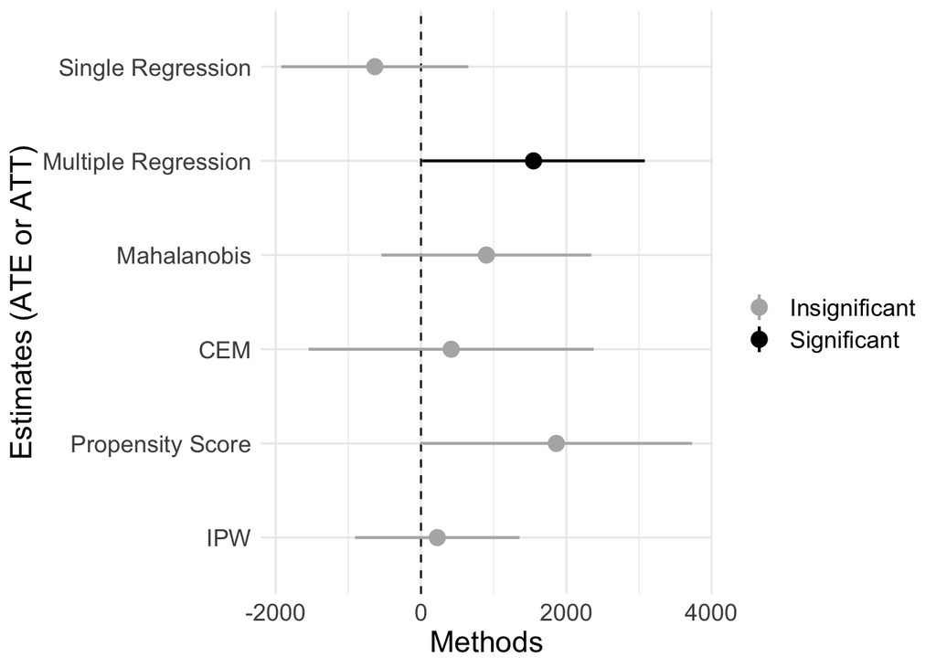

```r
Comparison.df %>%
    ggplot() +
    # x = 0の垂直線を引く。線の種類は破線 (linetype = 2)で
    geom_vline(xintercept = 0, linetype = 2) +
    # 点と線を同時に出力するgeom_pointrange幾何オブジェクトを使用
    # 点の位置 (x, y)はEst, Methodに、線の下限と上限 (xmin, xmax)はLL, UL
    # Sigの値によって色分けするためにcolor引数もマッピング
    geom_pointrange(aes(x = Est, y = Method, xmin = LL, xmax = UL,
                        color = Sig), size = 0.75) +
    # colorにマッピングされているSigの値がSignificantなら色をblackに
    # Insignificantならgray70にする
    scale_color_manual(values = c("Significant"   = "black",
                                  "Insignificant" = "gray70")) +
    # ラベルを付ける
    labs(x = "Methods", y = "Estimates (ATE or ATT)",
         color = "") +
    # minimalテーマを適用
    theme_minimal() +
    # 文字の大きさを調整
    theme(text = element_text(size = 16))
```

[^1]: これは重み変数を使わない最近傍マッチングをしても追加されます。ただし、その場合、`W`は全て1になります。
[^2]: 実は`nearest = "logit"`が省略されています。つまり、ロジスティック回帰分析から得られた傾向スコアの距離に基づくマッチングを意味します。
[^3]: ロジスティック回帰分析ではなくても問題ありません。他、プロッビット、サポートベクトルマシン、回帰木、判別分析、ニューラル・ネットワークなどもあり、これらを組わせることも可能です。
[^4]: [Imai, Kosuke and Marc Ratkovic. 2014. “Covariate Balancing Propensity Score.” *Journal of the Royal Statistical Society, Series B,* Vol. 76, No. 1, pp. 243-246.](https://imai.fas.harvard.edu/research/CBPS.html)
[^5]: Super Learnerを使った例は「Cyrus, Samii, Laura Paler, and Sarah Zukerman Daly. 2016. “Retrospective Causal Inference with Machine Learning Ensembles: An Application to Anti-recidivism Policies in Colombia.” *Political Analysis,* 22 (4) pp. 434-456」を、日本語による解説は担当教員の報告スライドを参照して下さい。